# R K-means

Jang, Eunhee

2018년 6월 12일

### 목차

1. k 평균 군집화 이론 수업
2. k 평균 군집화 실습
- 국영수 점수를 가지고 학생분류
- 소셜미디어에 같은 성향을 갖는 사람들을 분류
- 머신러닝의 종류 3가지0
1. 지도학습: 분류/예측
2. 비지도 학습: 클러스터링
3. 강화학습

#### k means 군집화 알고리즘이란?

> k 평균 알고리즘은 주어진 데이터를 k개의 클러스터로 묶는 알고리즘으로, 각 클러스터와 거리 차이의 분산을 최소화하는 방식으로 동작한다.  
> 이 알고리즘은 자율학습(비지도학습)의 일종으로 레이블이 달려있지 않은 입력 데이터에 레이블을 달아주는 역활을 수행한다.

#### 컴퓨터가 어떻게 클러스터 구성에 대한 사전지식 없이 레이블이 없는 데이터의 군집화를 가능하게 할까?

> 군집화는 클러스터 안에 있는 아이템들은 서로 아주 비슷해야하지만 클러스터 밖에 있는 아이템과는 아주 달라야한다는 원칙을 따른다.

#### k means 알고리즘의 목표

> k means알고리즘은 n개의 예시를 k개의 클러스터 중 하나에 할당하는데, 이때 k는 사전에 결정된 숫자.  
> 클러스터 내의 차이를 최소화하고 클러스터 간의 차이를 최대화하는 것이다.

#### k means vs k nn

> 공통점: **거리함수**를 이용해서 중심에서 가까운 거리에 있는 데이터를 클러스터링한다.  
> 차이점: knn 은 label이 있는 지도학습 방법이고, k means는 label이 없는 비지도 학습 방법

#### 유클리드 공식

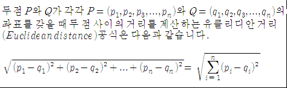

```r
# 과학 발표 5번 수학발표 1번
gest1 <- c(5,1)
# 과학 논문 0번 수학논문 2번
gest2 <- c(0,2)

euclide <- sqrt((gest1[1]-gest2[1])^2 + (gest1[2]-gest2[2]) ^ 2)
euclide
```

```
## [1] 5.09902
```

#### k means 알고리즘 방법

> 1. 초기 중심으로 k개의 랜덤한 점을 선택
> 2. 유클리드 거리공식 이용하여 적절한 중심으로 이동
- 값이 하나가 주어지면 중심점을 계산하거나 각 예시를 가장 가까운 클러스터에 할당함으로써 클러스터 경계를 정의할 수 있다.

#### 적절한 k 선택의 중요성

> k 값을 너무 크게 설정하면 그룹내 동질성이 올라가 과적합(overfitting)으로 일어날 수 있다.  
> k 값을 너무 작게 설정하면 분류를 잘 하지 못한다.(underfitting)

#### 사전에 데이터에 대한 지식이 없을 때 k값을 알아내는 방법?

> 1. k = sqrt(n/2)
> 2. elbow 방법: 동질성을 최대화하고 이질성을 최소화하는 것이 아니라 특정 포인트를 넘으면 결과가 약화되는 k를 찾는다.
> - 일반적으로 k를 정확히 구하는 데 대한 걱정하는 시간을 거의 쓰지 않는 것이 현명할 수 있다.

>군집화는 복잡성을 줄이고 관계패턴에 통찰력을 제공하는 의미가 있고 실행 가능한 데이터 구조를 만든다.  
실행가능하고 의미있는 레이블을 적용하는 것은 사람의 책임이다.  
그룹의 경계를 주관적으로 정의하는 것보다 머신 러닝을 이용해 객관적으로 정의 하는 것이 좋다.  
레이블이 없는 데이터의 클래스 레이블을 만들기 위해 군집화를 사용하여 예측변수를 찾는 의사결정 트리와 같은 지도학습을 적용하여 준지도 학습을 할 수 있다.

#### k means 기본 실습

```r
# 1. 기본 데이터 셋을 만든다. 무조건 수치형 데이터여야한다.
c <- c(3,4,1,5,7,9,5,4,6,8,4,5,9,8,7,8,6,7,2,1)
 row <- c("A","B","C","D","E","F","G","H","I","J")
 col <- c("X","Y")
data <- matrix( c, nrow= 10, ncol=2, byrow=TRUE, dimnames=list(row,col))

data
```

```
##   X Y
## A 3 4
## B 1 5
## C 7 9
## D 5 4
## E 6 8
## F 4 5
## G 9 8
## H 7 8
## I 6 7
## J 2 1
```

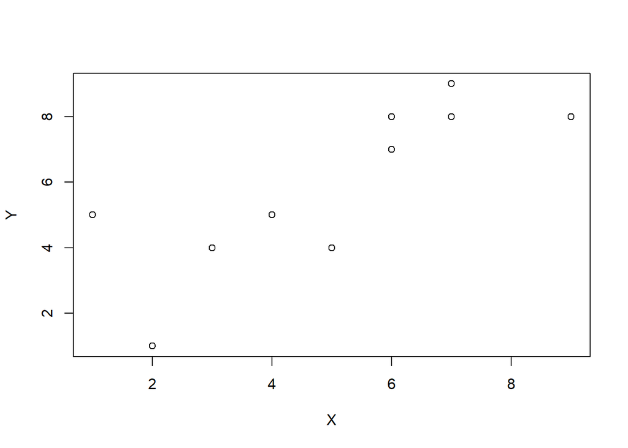

```r
# 2. plot 그래프를 그린다
plot(data)
```

```r
# 3. kmeans패키지를 설치한다.
# install.packages("stats")
library(stats)

# 4. kmeans 함수로 데이터를 분류한다.
# k개 구하는 공식: k = sqrt(n/2)
k = round(sqrt(length(data)/2))

# km <- kmeans(data,k)
km2 <- kmeans(data,2)
# kc <- km$centers
kc2 <- km2$centers
# cbind(data,km$cluster)
cbind(data,km2$cluster)
```

```
##   X Y
## A 3 4 1
## B 1 5 1
## C 7 9 2
## D 5 4 1
## E 6 8 2
## F 4 5 1
## G 9 8 2
## H 7 8 2
## I 6 7 2
## J 2 1 1
```

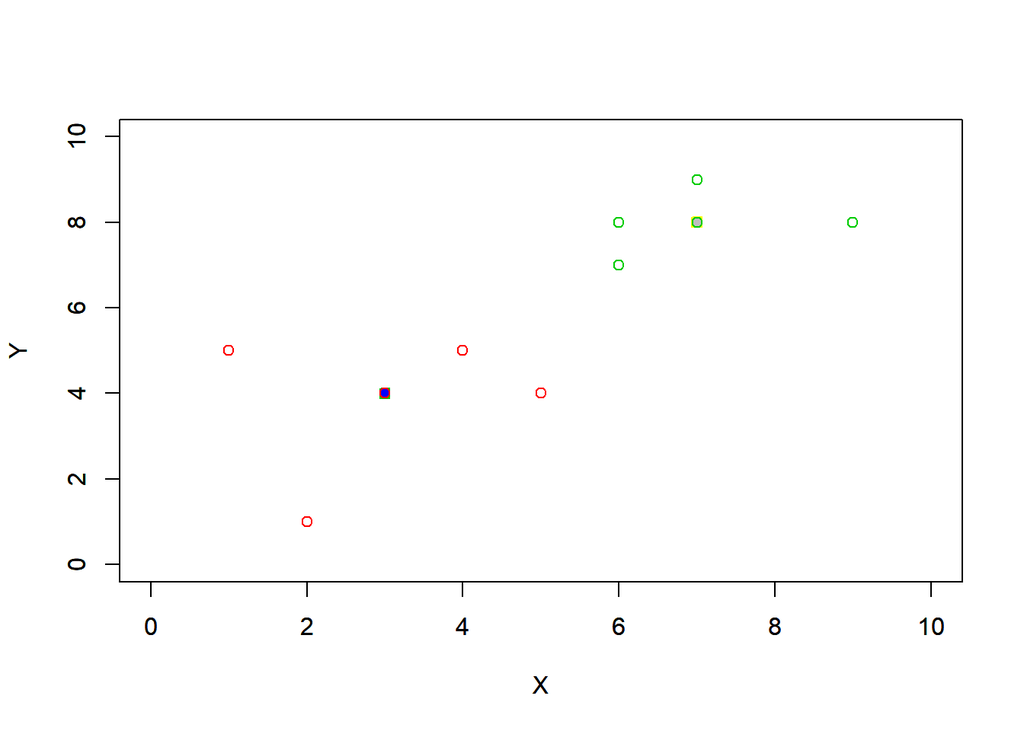

```r
# 5. 분류한 파라미터 값을 가지고 다시한번 시각화 한다.

# plot(round(kc), col = kc, pch=22, bg=kc, xlim = range(0:10), ylim = range(0:10))
#
# par(new=T)
#
# plot(data, col =km$cluster+1, xlim=range(0:10), ylim = range(0:10))

plot(round(kc2), col = kc2, pch=22, bg=kc2+1, xlim = range(0:10), ylim = range(0:10))

par(new=T)

plot(data, col =km2$cluster+1, xlim=range(0:10), ylim = range(0:10))
```

#### 문제335. factoextra 패키지를 이용하여 데이터를 시각화하시오

```r
# install.packages("factoextra")
library(factoextra)
```

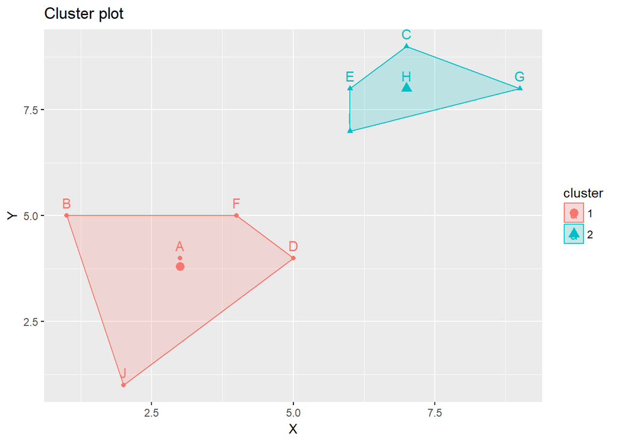

```r
fviz_cluster(km2, data = data, stand = F)
```

#### 문제336. 에러남

```r
# install.packages("tripack")

# library(tripack)
# library(RColorBrewer)
#
# color <- brewer.pal(2, "Pastel1")
# data_V <- voronoi.mosaic(kc2[,1], kc2[,2])
# data_P <- voronoi.polygons(data_V)
# plot(data, pch = 19, col = color[km$cluster])
# points(kc2[,1], kc2[,2], pch =3, cex = 1.5, lwd=2)
# plot(data_V, add = T)
```

#### 문제337. 실습1. 국영수 점수로 학생 분류

```r
# 1. 기본 데이터 셋을 만든다. 무조건 수치형 데이터여야한다.
data <- read.csv("C:/data/academy.csv")

str(data)
```

```
## 'data.frame':    52 obs. of  6 variables:
##  $ 학생번호    : int  1 2 3 4 5 6 7 8 9 10 ...
##  $ 국어점수평균: int  90 65 45 77 88 90 65 60 46 88 ...
##  $ 수학점수평균: int  75 90 53 96 89 92 70 90 56 67 ...
##  $ 영어점수평균: int  85 60 48 62 80 90 66 70 43 90 ...
##  $ 과학점수평균: int  60 88 50 92 82 96 76 98 55 70 ...
##  $ 학업집중도  : int  70 80 60 70 90 100 70 80 60 70 ...
```

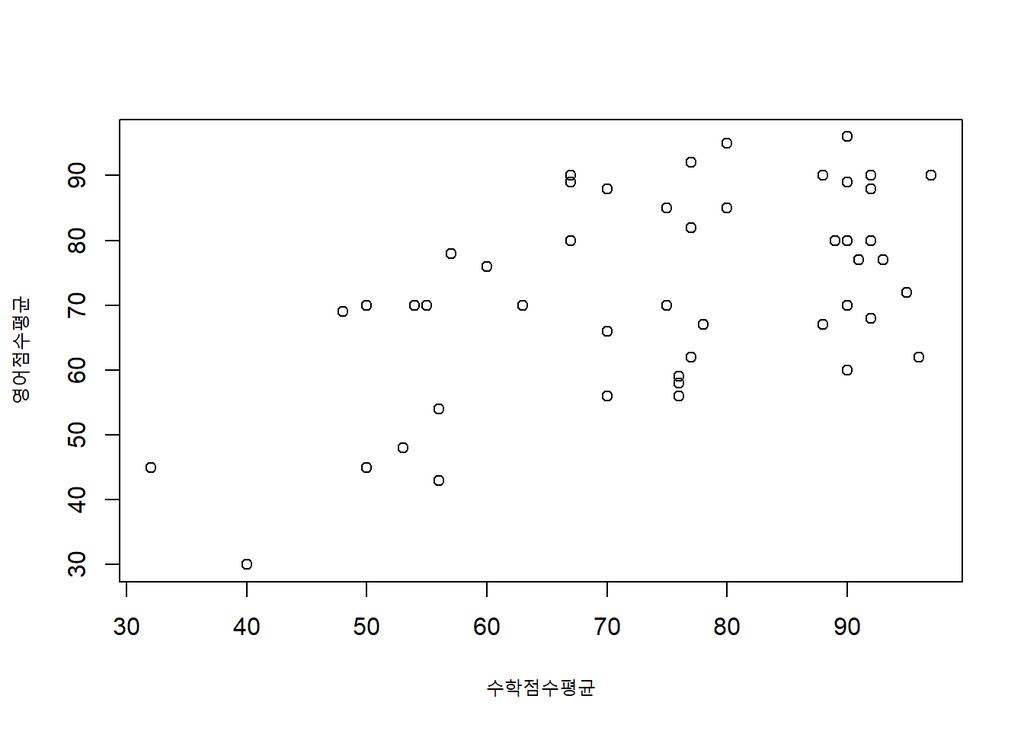

```r
data <- data[c(3,4)]

# 2. plot 그래프를 그린다
plot(data)
```

```r
# 3. kmeans패키지를 설치한다.
# install.packages("stats")
library(stats)

# 4. kmeans 함수로 데이터를 분류한다.
# k개 구하는 공식: k = sqrt(n/2)
# k = round(sqrt(length(data)/2))

# km <- kmeans(data,k)
km2 <- kmeans(data,4)
# kc <- km$centers
kc2 <- km2$centers
# cbind(data,km$cluster)
cbind(data,km2$cluster)
```

```
##    수학점수평균 영어점수평균 km2$cluster
## 1            75           85           1
## 2            90           60           3
## 3            53           48           2
## 4            96           62           3
## 5            89           80           3
## 6            92           90           1
## 7            70           66           4
## 8            90           70           3
## 9            56           43           2
## 10           67           90           1
## 11           93           77           3
## 12           80           95           1
## 13           67           80           4
## 14           40           30           2
```

[output cut: 38 more lines]

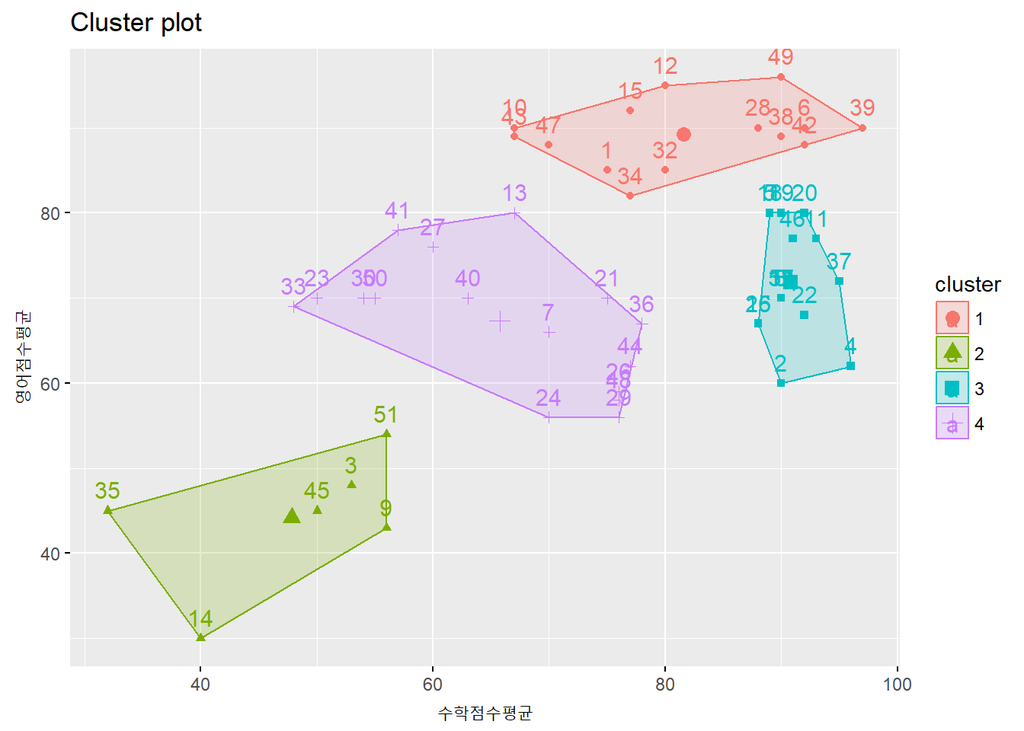

```r
# 5. 분류한 파라미터 값을 가지고 다시한번 시각화 한다.

# plot(round(kc), col = kc, pch=22, bg=kc, xlim = range(0:10), ylim = range(0:10))
#
# par(new=T)
#
# plot(data, col =km$cluster+1, xlim=range(0:10), ylim = range(0:10))

# plot(round(kc2), col = kc2, pch=22, bg=kc2-10, xlim = range(0:100), ylim = range(0:100))
#
# par(new=T)
#
# plot(data, col =km2$cluster+1, xlim=range(0:100), ylim = range(0:100))


# install.packages("factoextra")
library(factoextra)
fviz_cluster(km2, data = data, stand = F)
```

#### 문제338. 미국대학 입학 점수 데이터를 가지고 academic점수와 acceptance 점수로 4개의 클러스터로 분류하시오(to-be: 정규화해야함)

```r
academic <- read.csv("C:/data/sports.csv")

str(academic)
```

```
## 'data.frame':    200 obs. of  5 variables:
##  $ X         : int  1 2 3 4 5 6 7 8 9 10 ...
##  $ academic  : num  230.1 44.5 17.2 151.5 180.8 ...
##  $ sports    : num  37.8 39.3 45.9 41.3 10.8 48.9 32.8 19.6 2.1 2.6 ...
##  $ music     : num  62.9 41 63 68.5 53.1 ...
##  $ acceptance: num  81.9 38.5 34.4 68.5 47.8 ...
```

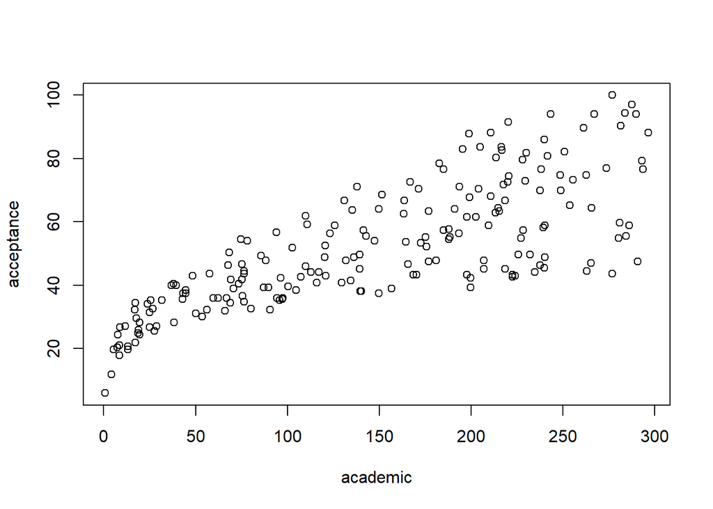

```r
academic <- academic[c(2,5)]

plot(academic)
```

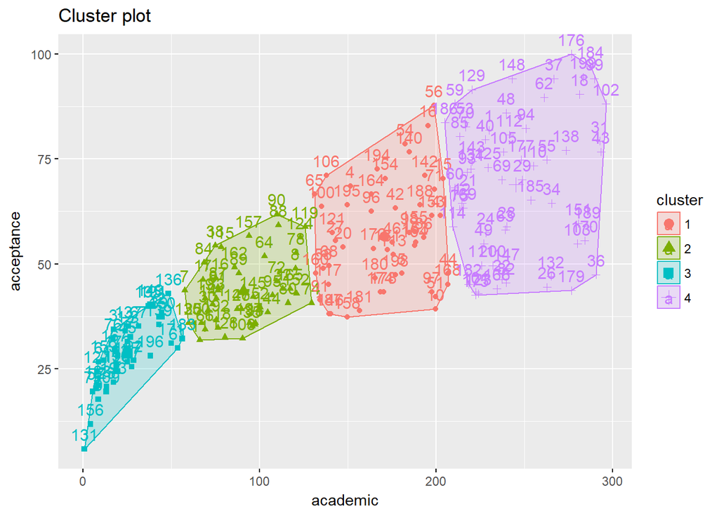

```r
km <- kmeans(academic,4)

kc <- km$centers

library(factoextra)
fviz_cluster(km, data = academic, stand = F)
```

#### 실습2 소셜미디어에 같은 성향을 갖는 사람들을 분류

```r
# 데이터 로드
teens <- read.csv("C:/data/snsdata.csv")

# 데이터 확인하기
str(teens)
```

```
## 'data.frame':    30000 obs. of  40 variables:
##  $ gradyear    : int  2006 2006 2006 2006 2006 2006 2006 2006 2006 2006 ...
##  $ gender      : Factor w/ 2 levels "F","M": 2 1 2 1 NA 1 1 2 1 1 ...
##  $ age         : num  19 18.8 18.3 18.9 19 ...
##  $ friends     : int  7 0 69 0 10 142 72 17 52 39 ...
##  $ basketball  : int  0 0 0 0 0 0 0 0 0 0 ...
##  $ football    : int  0 1 1 0 0 0 0 0 0 0 ...
##  $ soccer      : int  0 0 0 0 0 0 0 0 0 0 ...
##  $ softball    : int  0 0 0 0 0 0 0 1 0 0 ...
##  $ volleyball  : int  0 0 0 0 0 0 0 0 0 0 ...
##  $ swimming    : int  0 0 0 0 0 0 0 0 0 0 ...
##  $ cheerleading: int  0 0 0 0 0 0 0 0 0 0 ...
##  $ baseball    : int  0 0 0 0 0 0 0 0 0 0 ...
##  $ tennis      : int  0 0 0 0 0 0 0 0 0 0 ...
##  $ sports      : int  0 0 0 0 0 0 0 0 0 0 ...
```

[output cut: 26 more lines]

```r
nrow(teens)
```

```
## [1] 30000
```

```r
table(is.na(teens))
```

```
##
##   FALSE    TRUE
## 1192190    7810
```

```r
# gender 데이터 확인
table(teens$gender, useNA="ifany")
```

```
##
##     F     M  <NA>
## 22054  5222  2724
```

```r
# age 데이터 확인 및 정제
summary(teens$age)
```

```
##    Min. 1st Qu.  Median    Mean 3rd Qu.    Max.    NA's
##   3.086  16.312  17.287  17.994  18.259 106.927    5086
```

```r
teens$age <- ifelse(teens$age >= 13 & teens$age < 20, teens$age, NA)

summary(teens$age)
```

```
##    Min. 1st Qu.  Median    Mean 3rd Qu.    Max.    NA's
##   13.03   16.30   17.27   17.25   18.22   20.00    5523
```

```r
# 결측치 더미 코딩
teens$femaile <- ifelse(teens$gender == "F" & !is.na(teens$gender), 1,0)
teens$no_gender <- ifelse(is.na(teens$gender),1,0)
table(teens$femaile, useNA="ifany")
```

```
##
##     0     1
##  7946 22054
```

```r
table(teens$no_gender, useNA="ifany")
```

```
##
##     0     1
## 27276  2724
```

```r
head(teens)
```

```
##   gradyear gender    age friends basketball football soccer softball
## 1     2006      M 18.982       7          0        0      0        0
## 2     2006      F 18.801       0          0        1      0        0
## 3     2006      M 18.335      69          0        1      0        0
## 4     2006      F 18.875       0          0        0      0        0
## 5     2006   <NA> 18.995      10          0        0      0        0
## 6     2006      F     NA     142          0        0      0        0
##   volleyball swimming cheerleading baseball tennis sports cute sex sexy
## 1          0        0            0        0      0      0    0   0    0
## 2          0        0            0        0      0      0    1   0    0
## 3          0        0            0        0      0      0    0   0    0
## 4          0        0            0        0      0      0    1   0    0
## 5          0        0            0        0      0      0    0   1    0
## 6          0        0            0        0      0      0    0   1    0
##   hot kissed dance band marching music rock god church jesus bible hair
```

[output cut: 20 more lines]

```r
# 졸업년도로 결측치 예측하기
mean(teens$age, na.rm = TRUE)
```

```
## [1] 17.25243
```

```r
aggregate(data = teens, age~gradyear, mean, na.rm=TRUE)
```

```
##   gradyear      age
## 1     2006 18.65586
## 2     2007 17.70617
## 3     2008 16.76770
## 4     2009 15.81957
```

```r
ave_age <- ave(teens$age, teens$gradyear, FUN=function(x) mean(x, na.rm=TRUE))
table(ave_age)
```

```
## ave_age
## 15.8195733445096 16.7677007371007 17.7061723749799 18.6558579508727
##             7500             7500             7500             7500
```

```r
teens$age <- ifelse(is.na(teens$age), ave_age, teens$age)
summary(teens$age)
```

```
##    Min. 1st Qu.  Median    Mean 3rd Qu.    Max.
##   13.03   16.28   17.24   17.24   18.21   20.00
```

```r
# 관심사 정규화
str(teens)
```

```
## 'data.frame':    30000 obs. of  42 variables:
##  $ gradyear    : int  2006 2006 2006 2006 2006 2006 2006 2006 2006 2006 ...
##  $ gender      : Factor w/ 2 levels "F","M": 2 1 2 1 NA 1 1 2 1 1 ...
##  $ age         : num  19 18.8 18.3 18.9 19 ...
##  $ friends     : int  7 0 69 0 10 142 72 17 52 39 ...
##  $ basketball  : int  0 0 0 0 0 0 0 0 0 0 ...
##  $ football    : int  0 1 1 0 0 0 0 0 0 0 ...
##  $ soccer      : int  0 0 0 0 0 0 0 0 0 0 ...
##  $ softball    : int  0 0 0 0 0 0 0 1 0 0 ...
##  $ volleyball  : int  0 0 0 0 0 0 0 0 0 0 ...
##  $ swimming    : int  0 0 0 0 0 0 0 0 0 0 ...
##  $ cheerleading: int  0 0 0 0 0 0 0 0 0 0 ...
##  $ baseball    : int  0 0 0 0 0 0 0 0 0 0 ...
##  $ tennis      : int  0 0 0 0 0 0 0 0 0 0 ...
##  $ sports      : int  0 0 0 0 0 0 0 0 0 0 ...
```

[output cut: 28 more lines]

```r
ncol(teens)
```

```
## [1] 42
```

```r
# 36개의 특징만을 고려함(저자)
interests <- teens[5:40]
interests_z <- as.data.frame(lapply(interests, scale))
head(interests_z)
```

```
##   basketball   football     soccer   softball volleyball   swimming
## 1 -0.3322117 -0.3576914 -0.2428701 -0.2179242 -0.2236659 -0.2599662
## 2 -0.3322117  1.0600312 -0.2428701 -0.2179242 -0.2236659 -0.2599662
## 3 -0.3322117  1.0600312 -0.2428701 -0.2179242 -0.2236659 -0.2599662
## 4 -0.3322117 -0.3576914 -0.2428701 -0.2179242 -0.2236659 -0.2599662
## 5 -0.3322117 -0.3576914 -0.2428701 -0.2179242 -0.2236659 -0.2599662
## 6 -0.3322117 -0.3576914 -0.2428701 -0.2179242 -0.2236659 -0.2599662
##   cheerleading   baseball     tennis     sports       cute        sex
## 1   -0.2073236 -0.2011273 -0.1689361 -0.2971184 -0.4023555 -0.1863812
## 2   -0.2073236 -0.2011273 -0.1689361 -0.2971184  0.8438417 -0.1863812
## 3   -0.2073236 -0.2011273 -0.1689361 -0.2971184 -0.4023555 -0.1863812
## 4   -0.2073236 -0.2011273 -0.1689361 -0.2971184  0.8438417 -0.1863812
## 5   -0.2073236 -0.2011273 -0.1689361 -0.2971184 -0.4023555  0.7036915
## 6   -0.2073236 -0.2011273 -0.1689361 -0.2971184 -0.4023555  0.7036915
##         sexy        hot    kissed      dance       band   marching
```

[output cut: 27 more lines]

```r
# kmeans알고리즘을 돌림
set.seed(2345)
teen_clusters <- kmeans(interests_z,5)

# 클러스터의 크기(n)
teen_clusters$size
```

```
## [1]   871   600  5981  1034 21514
```

```r
# 클러스터의 중심점 좌표를 확인한다.
teen_clusters$centers
```

```
##    basketball   football      soccer    softball  volleyball    swimming
## 1  0.16001227  0.2364174  0.10385512  0.07232021  0.18897158  0.23970234
## 2 -0.09195886  0.0652625 -0.09932124 -0.01739428 -0.06219308  0.03339844
## 3  0.52755083  0.4873480  0.29778605  0.37178877  0.37986175  0.29628671
## 4  0.34081039  0.3593965  0.12722250  0.16384661  0.11032200  0.26943332
## 5 -0.16695523 -0.1641499 -0.09033520 -0.11367669 -0.11682181 -0.10595448
##   cheerleading    baseball      tennis      sports        cute
## 1    0.3931445  0.02993479  0.13532387  0.10257837  0.37884271
## 2   -0.1101103 -0.11487510  0.04062204 -0.09899231 -0.03265037
## 3    0.3303485  0.35231971  0.14057808  0.32967130  0.54442929
## 4    0.1856664  0.27527088  0.10980958  0.79711920  0.47866008
## 5   -0.1136077 -0.10918483 -0.05097057 -0.13135334 -0.18878627
##            sex        sexy         hot      kissed       dance        band
## 1  0.020042068  0.11740551  0.41389104  0.06787768  0.22780899 -0.10257102
## 2 -0.042486141 -0.04329091 -0.03812345 -0.04554933  0.04573186  4.06726666
```

[output cut: 27 more lines]

#### 소개팅 호감도 분석 label을 이용하여 정확도 확인하기

```r
like_r <- read.csv("C:/data/like.csv")
str(like_r)
```

```
## 'data.frame':    14 obs. of  8 variables:
##  $ manytalk  : int  30 60 50 90 50 70 40 30 80 50 ...
##  $ likebook  : int  80 50 40 50 70 30 90 60 40 70 ...
##  $ liketravel: int  40 70 80 60 30 60 60 90 20 70 ...
##  $ grade     : int  40 50 60 30 70 40 60 60 80 50 ...
##  $ tall      : int  90 60 50 40 70 40 60 40 60 70 ...
##  $ skin      : int  90 60 70 20 80 40 80 70 40 90 ...
##  $ muscle    : int  50 90 80 30 60 30 60 70 50 50 ...
##  $ likelabel : Factor w/ 3 levels "1타입","2타입",..: 1 2 2 3 1 3 1 2 3 1 ...
```

```r
like <- like_r[-8]

set.seed(123)
like_model <- kmeans(like,3)

be <- cbind(like_model$cluster, like_r$likelabel)
table(ifelse( be[,1]== be[,2],1,0))
```

```
##
##  1
## 14
```

label을 숫자로 1: 포유류 2 : 조류 3 : 파충류 4 : 어류 5 : 양서류 6 : 곤충 7 : 갑각류

```r
zoo_r <- read.csv("C:/data/zoo.csv")
head(zoo_r)
```

```
##   animal.name hair feathers eggs milk airborne aquatic predator toothed
## 1    aardvark    1        0    0    1        0       0        1       1
## 2    antelope    1        0    0    1        0       0        0       1
## 3        bass    0        0    1    0        0       1        1       1
## 4        bear    1        0    0    1        0       0        1       1
## 5        boar    1        0    0    1        0       0        1       1
## 6     buffalo    1        0    0    1        0       0        0       1
##   backbone breathes venomous fins legs tail domestic catsize type
## 1        1        1        0    0    4    0        0       1    1
## 2        1        1        0    0    4    1        0       1    1
## 3        1        0        0    1    0    1        0       0    4
## 4        1        1        0    0    4    0        0       1    1
## 5        1        1        0    0    4    1        0       1    1
## 6        1        1        0    0    4    1        0       1    1
```

```r
str(zoo_r)
```

```
## 'data.frame':    101 obs. of  18 variables:
##  $ animal.name: Factor w/ 100 levels "aardvark","antelope",..: 1 2 3 4 5 6 7 8 9 10 ...
##  $ hair       : int  1 1 0 1 1 1 1 0 0 1 ...
##  $ feathers   : int  0 0 0 0 0 0 0 0 0 0 ...
##  $ eggs       : int  0 0 1 0 0 0 0 1 1 0 ...
##  $ milk       : int  1 1 0 1 1 1 1 0 0 1 ...
##  $ airborne   : int  0 0 0 0 0 0 0 0 0 0 ...
##  $ aquatic    : int  0 0 1 0 0 0 0 1 1 0 ...
##  $ predator   : int  1 0 1 1 1 0 0 0 1 0 ...
##  $ toothed    : int  1 1 1 1 1 1 1 1 1 1 ...
##  $ backbone   : int  1 1 1 1 1 1 1 1 1 1 ...
##  $ breathes   : int  1 1 0 1 1 1 1 0 0 1 ...
##  $ venomous   : int  0 0 0 0 0 0 0 0 0 0 ...
##  $ fins       : int  0 0 1 0 0 0 0 1 1 0 ...
##  $ legs       : int  4 4 0 4 4 4 4 0 0 4 ...
##  $ tail       : int  0 1 1 0 1 1 1 1 1 0 ...
##  $ domestic   : int  0 0 0 0 0 0 1 1 0 1 ...
##  $ catsize    : int  1 1 0 1 1 1 1 0 0 0 ...
##  $ type       : int  1 1 4 1 1 1 1 4 4 1 ...
```

```r
n <- which(colnames(zoo_r) == "type")

zoo <- zoo_r[-c(1,n)]
str(zoo)
```

```
## 'data.frame':    101 obs. of  16 variables:
##  $ hair    : int  1 1 0 1 1 1 1 0 0 1 ...
##  $ feathers: int  0 0 0 0 0 0 0 0 0 0 ...
##  $ eggs    : int  0 0 1 0 0 0 0 1 1 0 ...
##  $ milk    : int  1 1 0 1 1 1 1 0 0 1 ...
##  $ airborne: int  0 0 0 0 0 0 0 0 0 0 ...
##  $ aquatic : int  0 0 1 0 0 0 0 1 1 0 ...
##  $ predator: int  1 0 1 1 1 0 0 0 1 0 ...
##  $ toothed : int  1 1 1 1 1 1 1 1 1 1 ...
##  $ backbone: int  1 1 1 1 1 1 1 1 1 1 ...
##  $ breathes: int  1 1 0 1 1 1 1 0 0 1 ...
##  $ venomous: int  0 0 0 0 0 0 0 0 0 0 ...
##  $ fins    : int  0 0 1 0 0 0 0 1 1 0 ...
##  $ legs    : int  4 4 0 4 4 4 4 0 0 4 ...
##  $ tail    : int  0 1 1 0 1 1 1 1 1 0 ...
##  $ domestic: int  0 0 0 0 0 0 1 1 0 1 ...
##  $ catsize : int  1 1 0 1 1 1 1 0 0 0 ...
```

```r
set.seed(55)

zoo_model <- kmeans(zoo,7)

cbind(zoo_model$cluster, zoo_r[n])
```

```
##     zoo_model$cluster type
## 1                   1    1
## 2                   1    1
## 3                   7    4
## 4                   1    1
## 5                   1    1
## 6                   1    1
## 7                   1    1
## 8                   6    4
## 9                   7    4
## 10                  1    1
## 11                  1    1
## 12                  2    2
## 13                  7    4
## 14                  4    7
```

[output cut: 87 more lines]

```r
zoo_model$cluster <- ifelse(zoo_model$cluster == 7, 4, ifelse(zoo_model$cluster == 4,7, zoo_model$cluster))
be <- cbind(zoo_model$cluster, zoo_r[n])

head(cbind(zoo_model$cluster, zoo_r[n]))
```

```
##   zoo_model$cluster type
## 1                 1    1
## 2                 1    1
## 3                 4    4
## 4                 1    1
## 5                 1    1
## 6                 1    1
```

```r
table(ifelse(be[,1]== be[,2],1,0))
```

```
##
##  0  1
## 28 73
```

#### 문제341. 부도여부 데이터를 kmeans 머신러닝 기법으로 분류해서 라벨과 일치하는지 확인해보시오.

```r
bankrupt <- read.csv("C:/data/부도예측데이터3.csv")

colnames(bankrupt) <- c("class","매출액","자기자본","총자본투자효율","부가가치율","매출액증가율","재고자산증가율","총자산증가율","금융비용대매출액비율","대출효율성계수","매출액순이익률","매출원가율","손익분기점율","순금융비용대매출액비율","이자보상배율","자기자본순이익률","총자본경상이익률","총자본순이익률","고정장기적합율의역","단기부채대총차입금","당좌비율","매출채권대매입채무","순운전자본비율","유동비율","유동부채대총자본","유보액대총자산비율","자기자본비율","차입금의존도","총차입금대매출액","금융비용부담율증가분","매입채무회전율","순운전자본대매출액","운전자금대매출액","재고자산회전율","총자본회전율","현금흐름지표(1)","현금흐름지표(2)","현금흐름지표(3)","현금흐름지표(4)","현금흐름지표(5)","현금흐름지표(6)","현금흐름지표(7)","현금흐름지표(8)","현금흐름지표(9)" )

head(bankrupt)
```

```
##   class   매출액 자기자본 총자본투자효율 부가가치율 매출액증가율
## 1     1 9.706377 6.810142         19.121      7.837      -20.915
## 2     1 7.962416 6.208590         38.240     31.800       43.693
## 3     0 7.392648 4.934474         56.551     15.147       23.592
## 4     1 7.597898 5.736572         42.857     14.292       43.867
## 5     1 9.235326 7.185387         31.098     10.065       11.883
## 6     0 8.839277 6.186209         43.988     15.855      -13.010
##   재고자산증가율 총자산증가율 금융비용대매출액비율 대출효율성계수
## 1         14.692        0.850                3.172         26.801
## 2         10.232        7.789                5.050         66.781
## 3        152.941       30.769                3.263        187.041
## 4        -48.101       22.036                2.607         77.228
## 5        -18.307       26.905                2.877         81.661
## 6         -4.836      -11.733                1.666         86.653
##   매출액순이익률 매출원가율 손익분기점율 순금융비용대매출액비율
```

[output cut: 62 more lines]

```r
bankrupt_r <- bankrupt[-1]

bankrupt_n <- as.data.frame(lapply(bankrupt_r,scale))

set.seed(12)
bankrupt_model <- kmeans(bankrupt_n, 2)

# bankrupt_model$cluster <- ifelse(bankrupt_model$cluster == 2, 0,bankrupt_model$cluster)
bankrupt_model$cluster <- ifelse(bankrupt_model$cluster == 2, 1,0)
be <- cbind(bankrupt_model$cluster, bankrupt[1])
table(ifelse(be[,1]== be[,2],"O","X"))
```

```
##
##   O   X
## 669 531
```